# TIGPS2023手足問卷成果報告

#感謝您參與中央研究院臺灣數位世代青少年的成長歷程追蹤研究計畫，本研究第一年完成訪問的學生來自全國170多所不同的學校，共計8,958位。2023年每位學生可以有三位手足填寫手足問卷，共計回收675份手足問卷，以下是問卷的調查結果，歡迎參閱！

### 與國七學生關係 (樣本數=674)

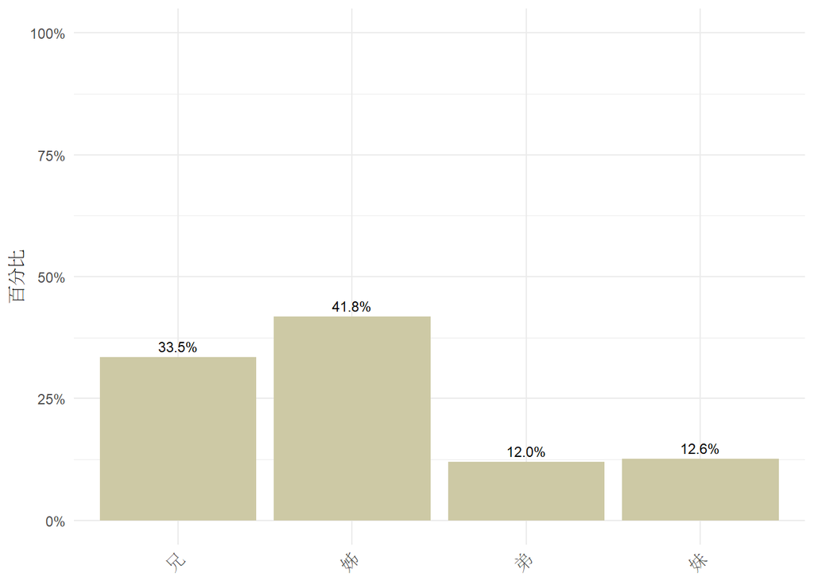

### 手足性別 (樣本數=674)

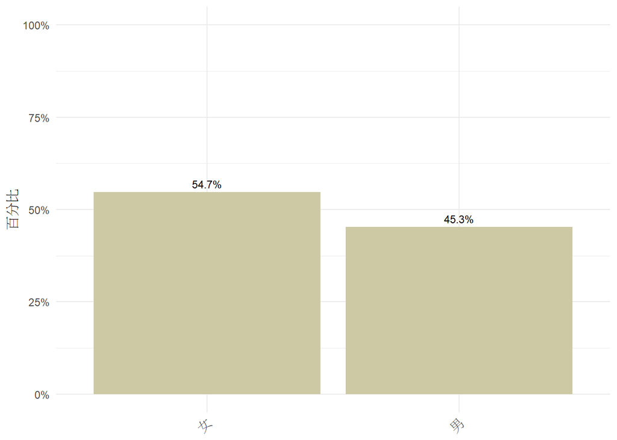

### 同住家人_親生父親 (樣本數=672)

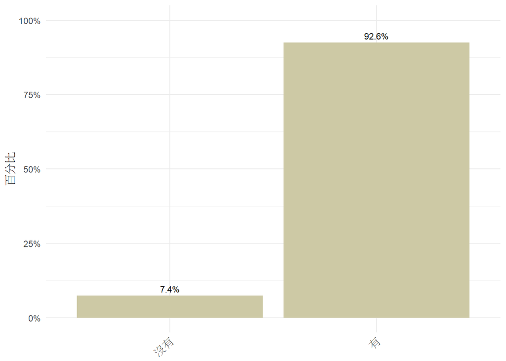

### 同住家人_親生母親 (樣本數=672)

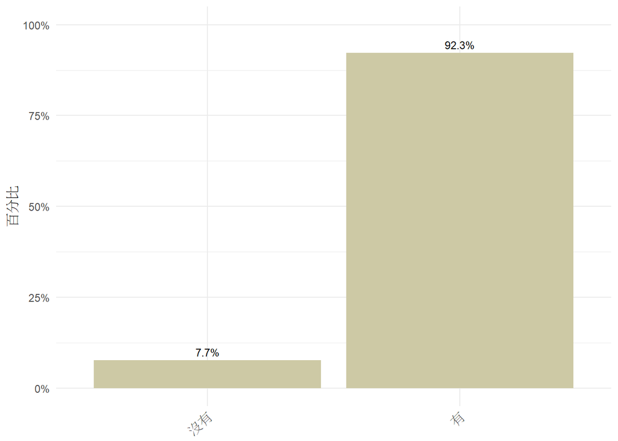

### 同住家人_養父/繼父 (樣本數=672)

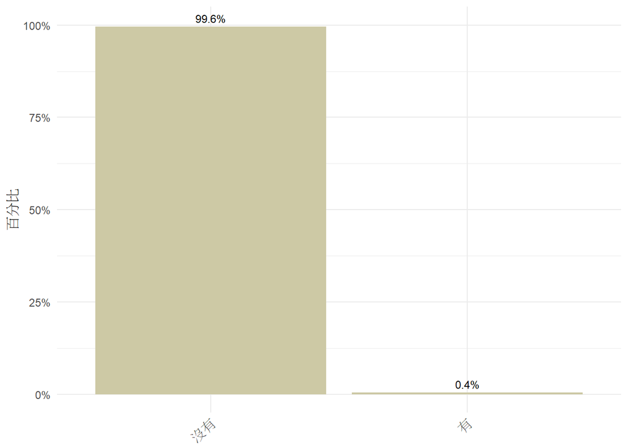

### 同住家人_未婚兄弟 (樣本數=672)

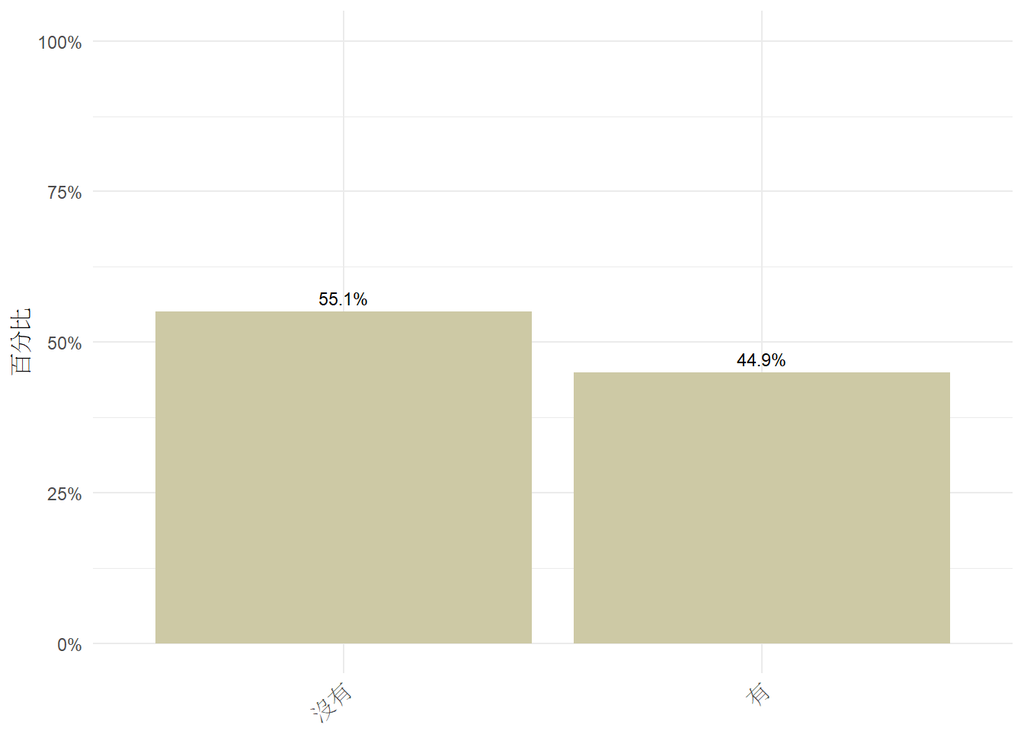

### 同住家人_未婚姊妹 (樣本數=672)

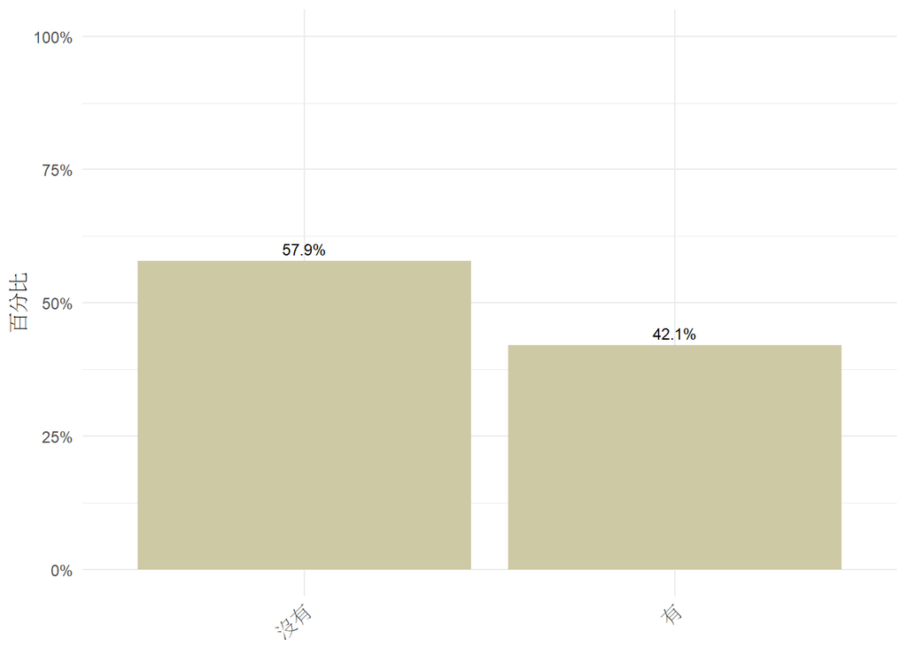

### 同住家人_祖父 (樣本數=672)

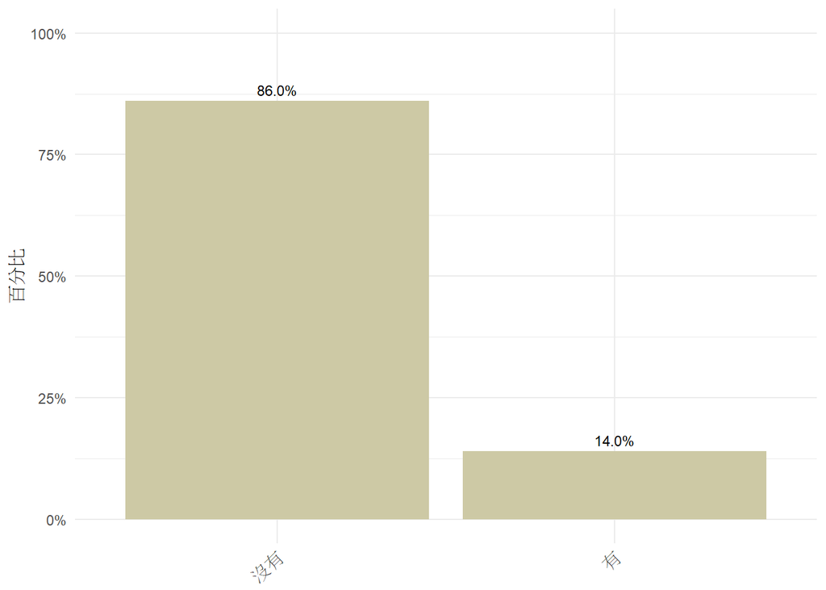

### 同住家人_祖母 (樣本數=672)

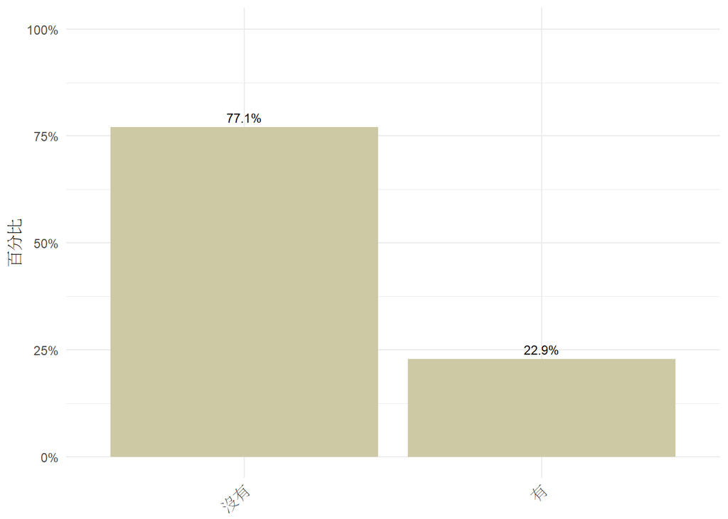

### 同住家人_外祖父 (樣本數=672)

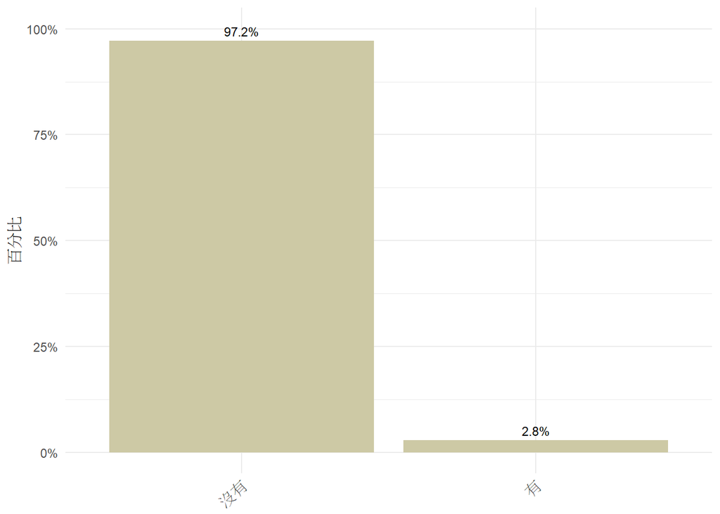

### 同住家人_外祖母 (樣本數=672)

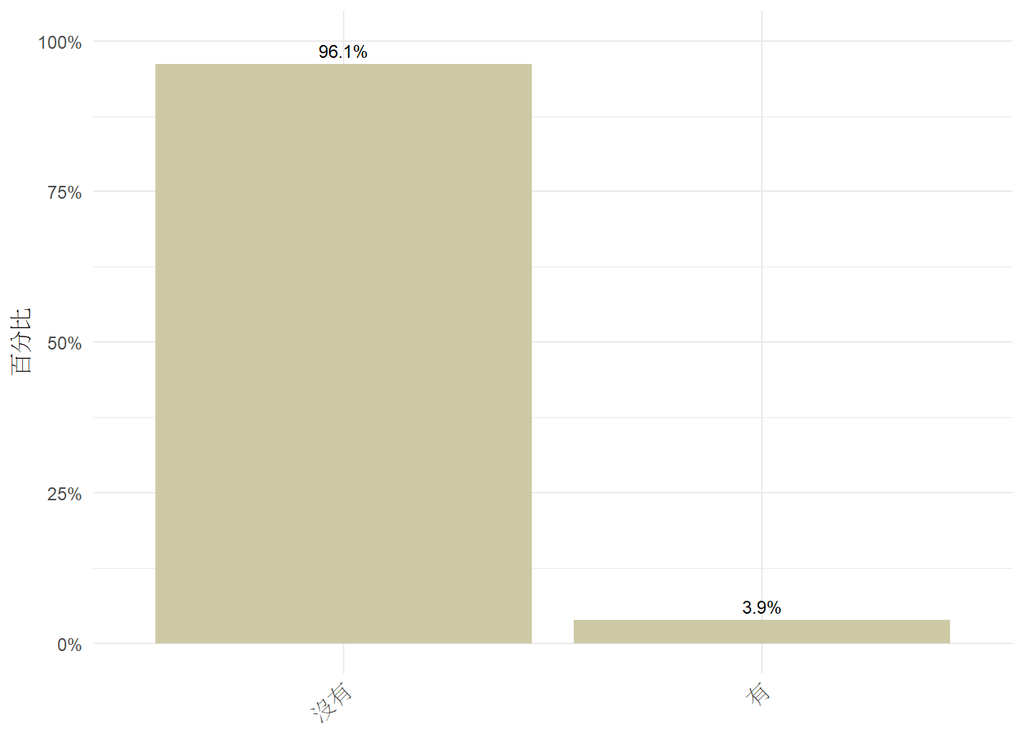

### 同住家人_伯父、伯母 (樣本數=672)

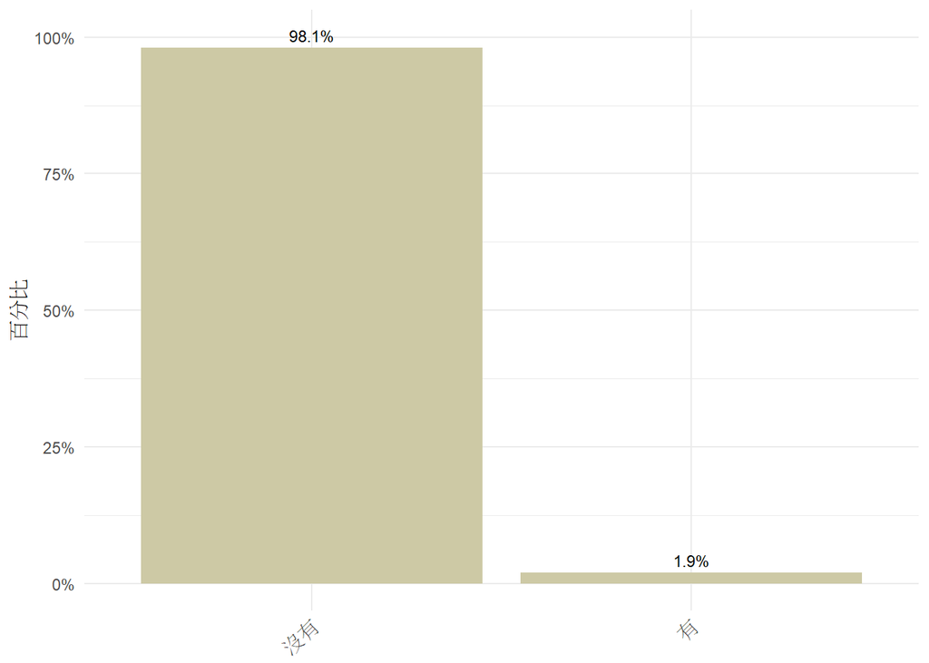

### 同住家人_叔叔、嬸嬸 (樣本數=672)

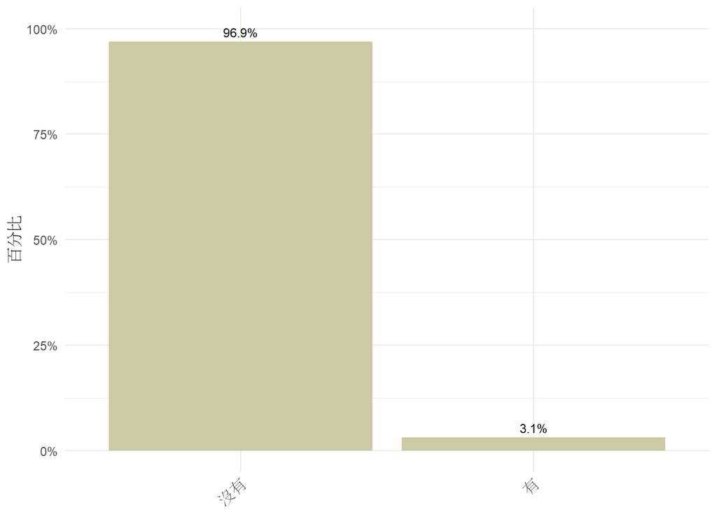

### 同住家人_姑姑、姑丈 (樣本數=672)

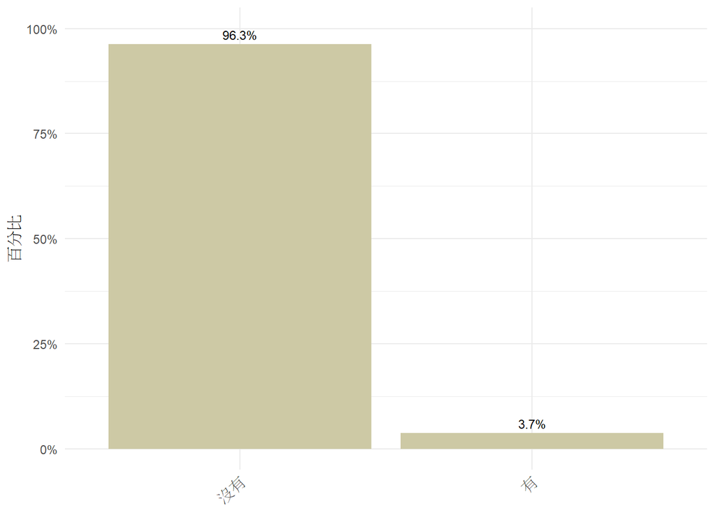

### 同住家人_表／堂兄姊 (樣本數=672)

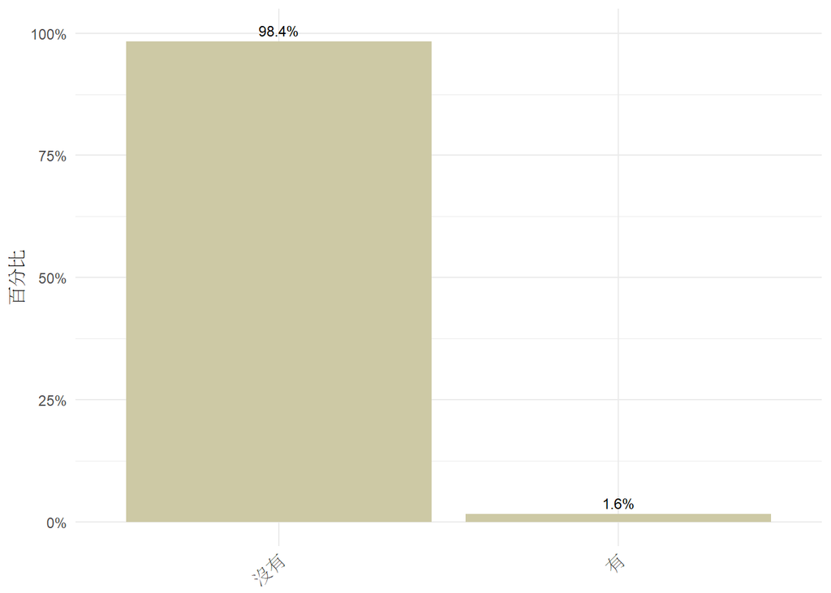

### 同住家人_表／堂弟妹 (樣本數=672)

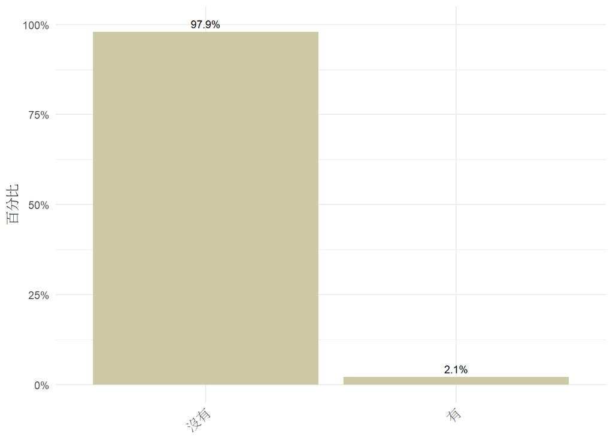

### 同住家人_看護或幫傭 (樣本數=672)

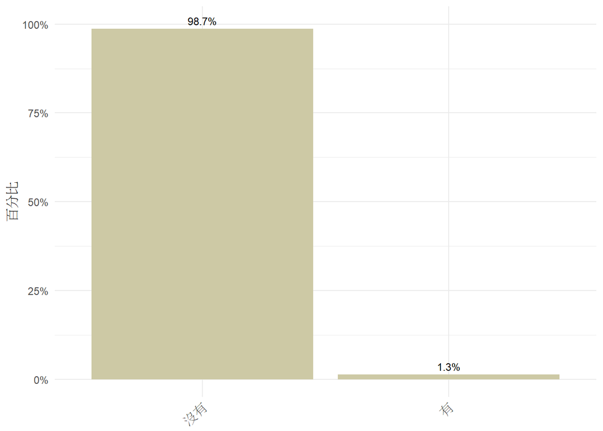

### 同住家人_其他 (樣本數=672)

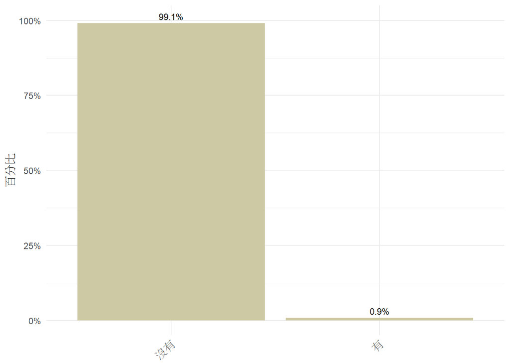

### 家庭凝聚力_作決定時，家人會彼此商量 (樣本數=652)

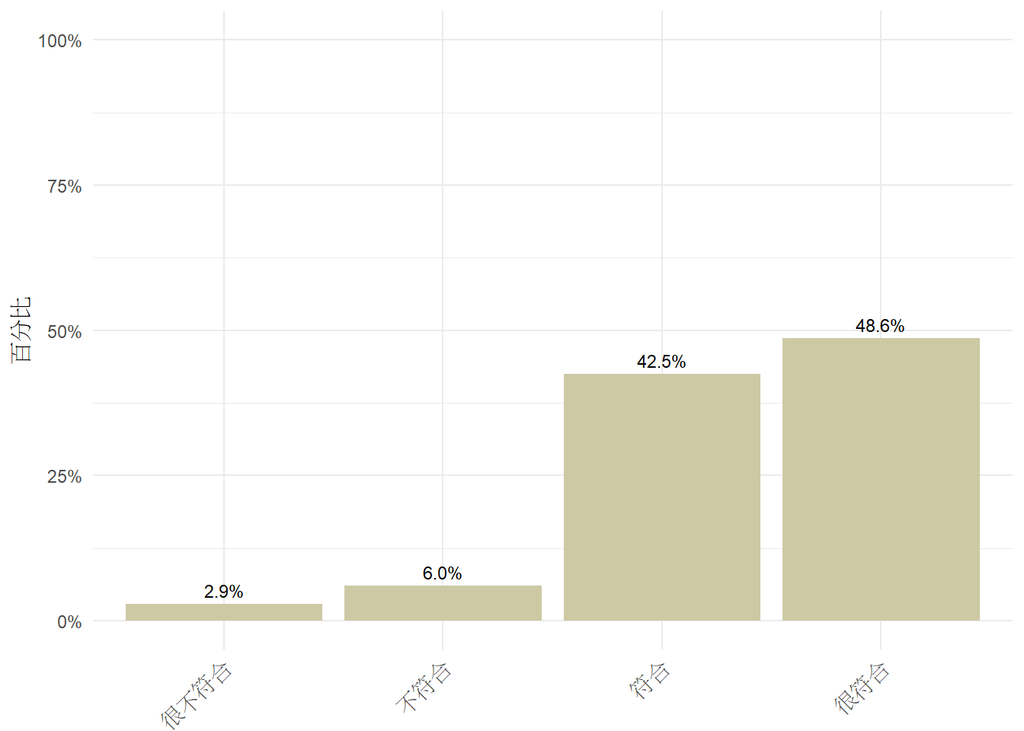

### 家庭凝聚力_家人喜歡共度休閒時光 (樣本數=652)

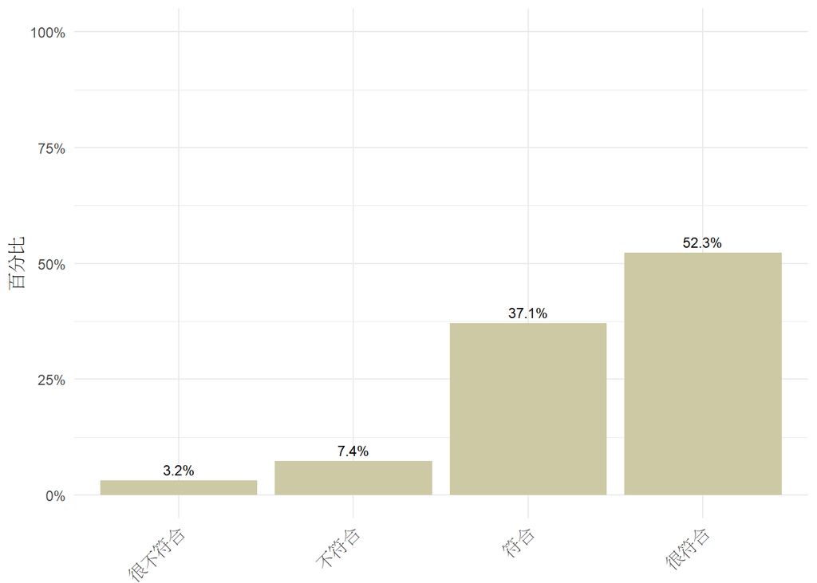

### 家庭凝聚力_當有家庭活動時，我們家每個人都會參加 (樣本數=652)

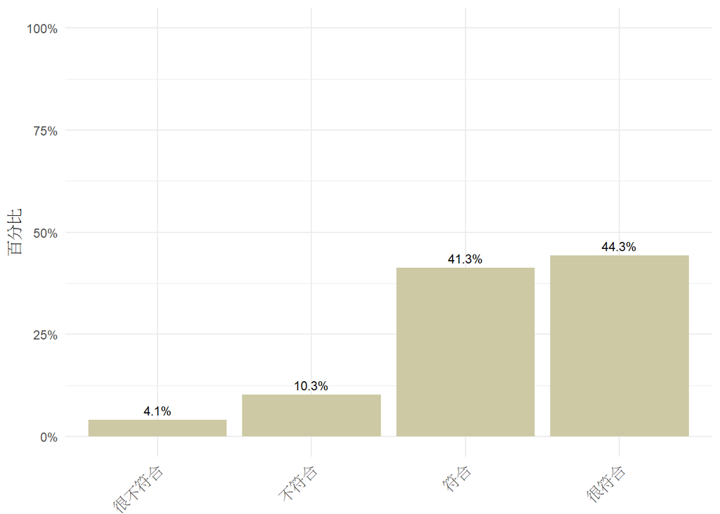

### 家庭凝聚力_家人會接納彼此的朋友 (樣本數=652)

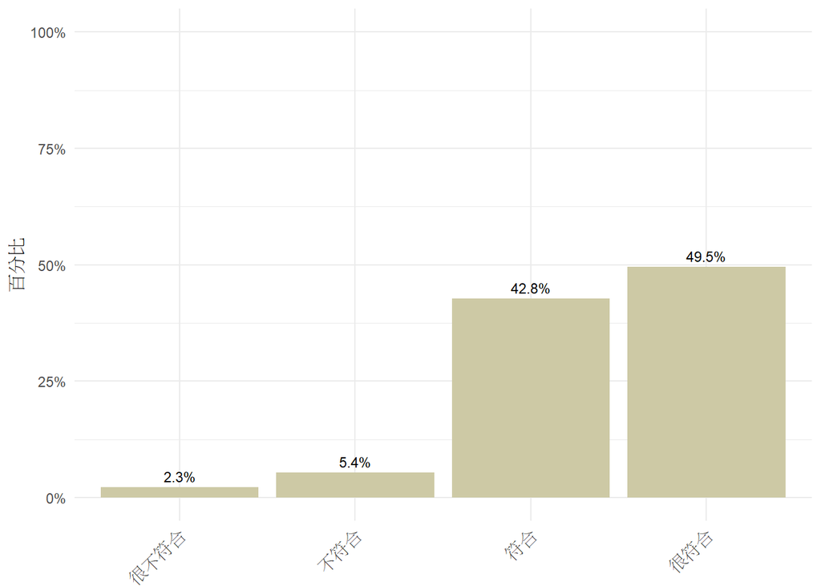

### 家庭凝聚力_受到挫折時，總可以從我的家人那裡得到安慰 (樣本數=652)

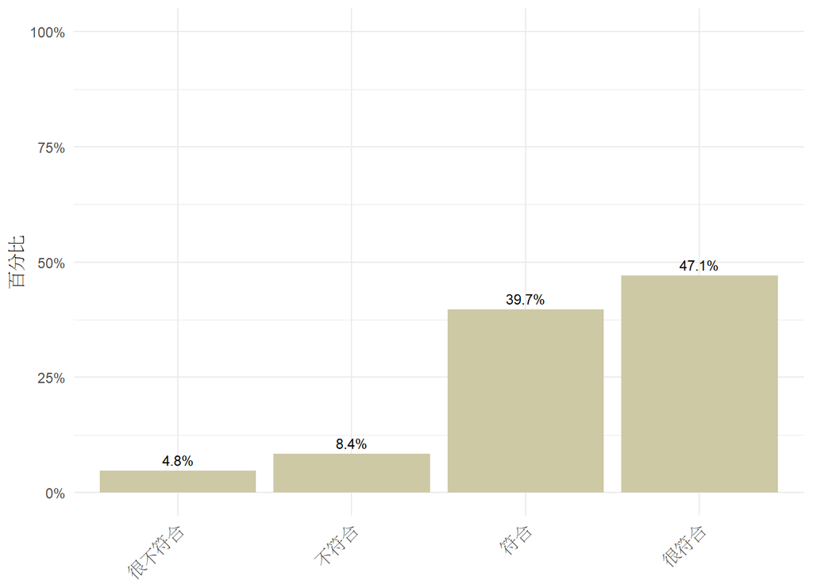

### 家庭凝聚力_當我需要幫忙或忠告時，我可以依賴我的家人 (樣本數=652)

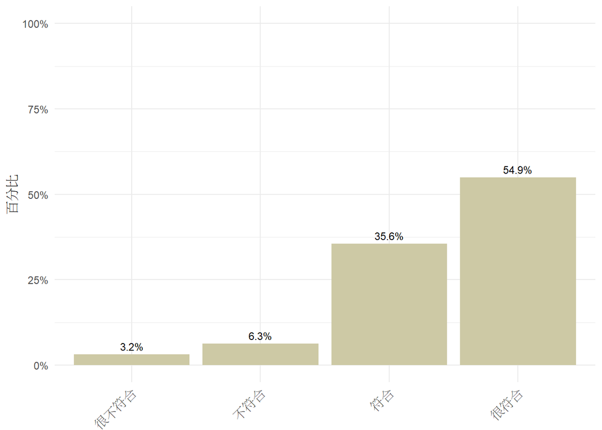

### 家庭經濟狀況 (樣本數=651)

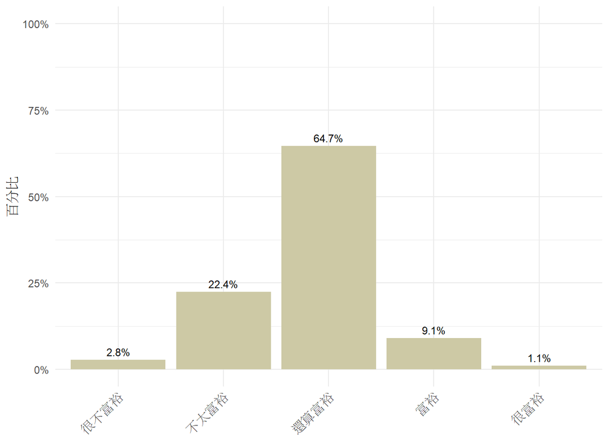

### 宗教信仰 (樣本數=648)

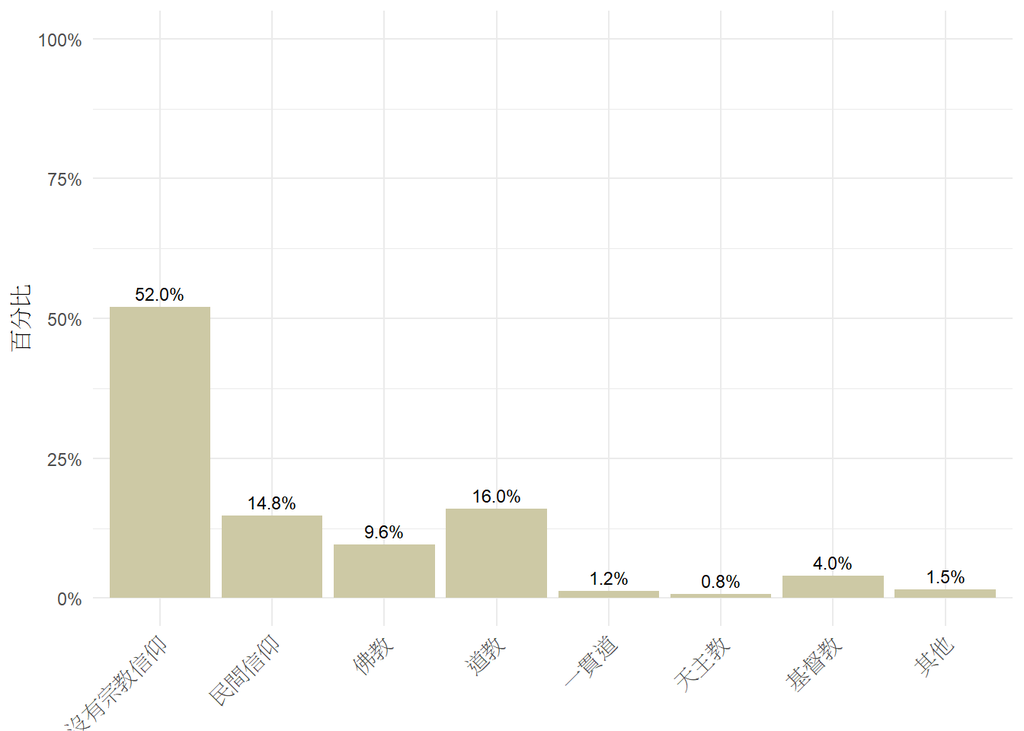

### 教育階段_目前在學校唸書 (樣本數=649)

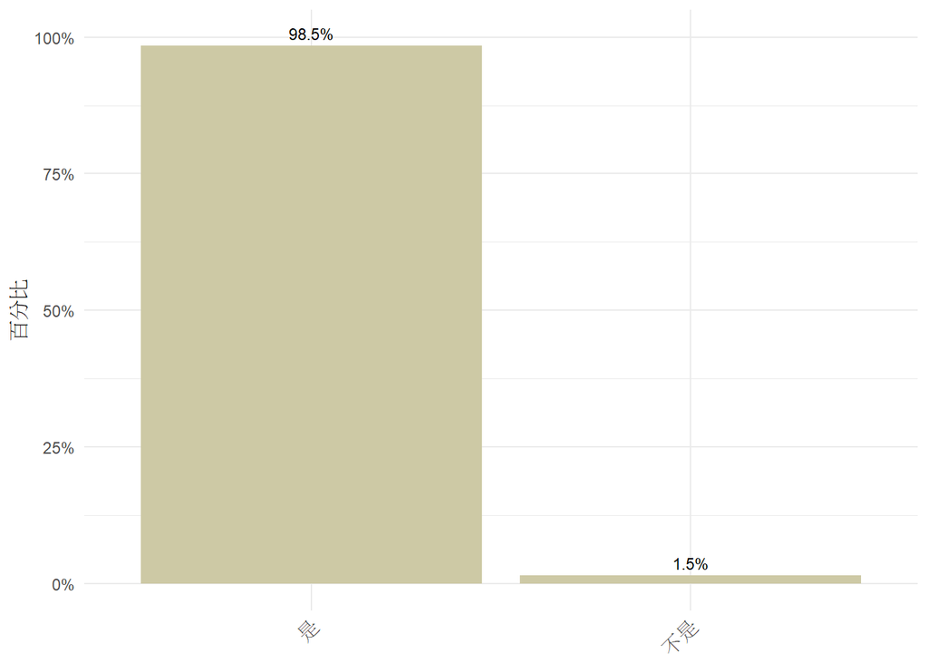

### 教育、工作狀況 (樣本數=9)

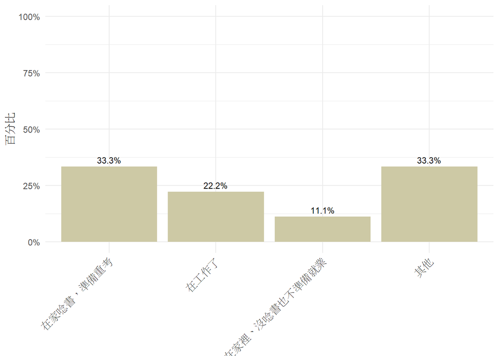

### 教育階段_在哪裡唸書 (樣本數=628)

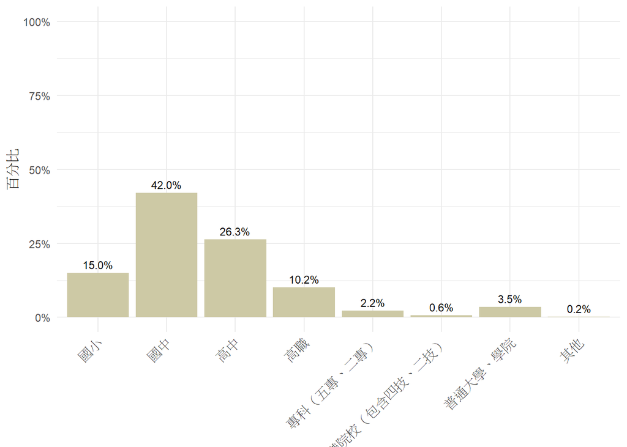

### 教育階段_學校公私立 (樣本數=625)

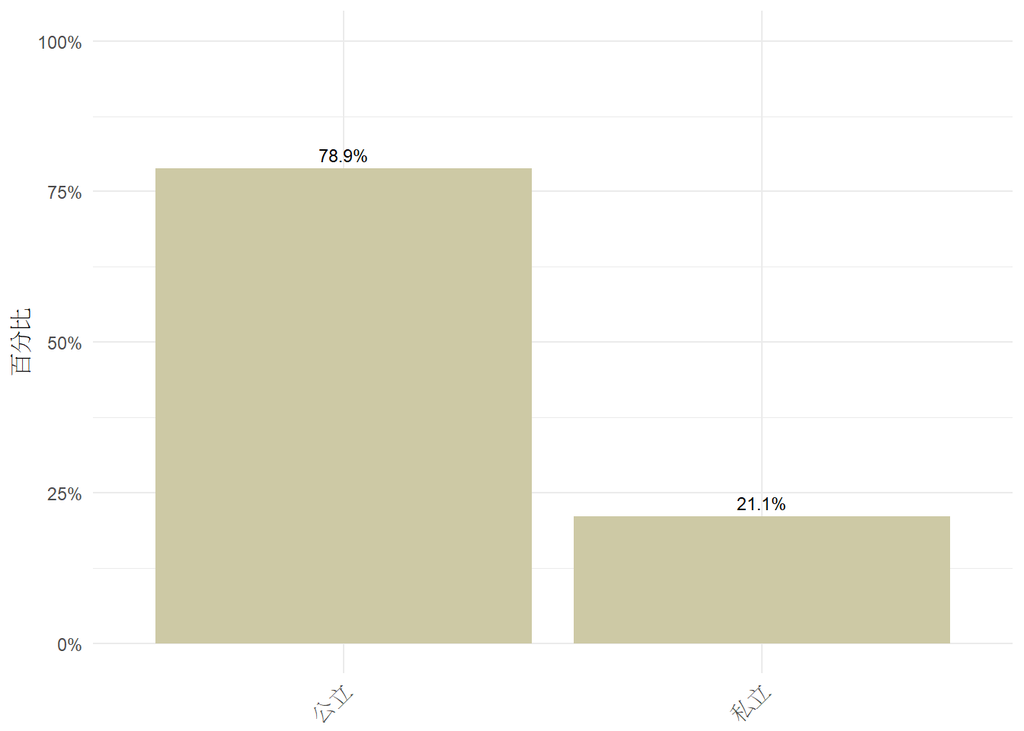

### 學校生活滿意 (樣本數=624)

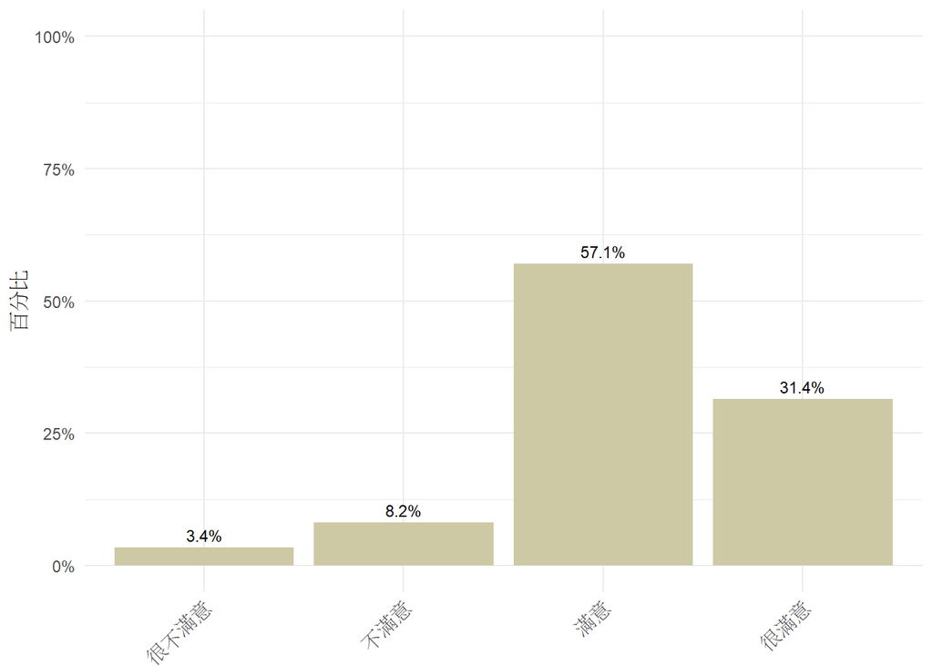

### 對校態度_是一個安全的地方 (樣本數=623)

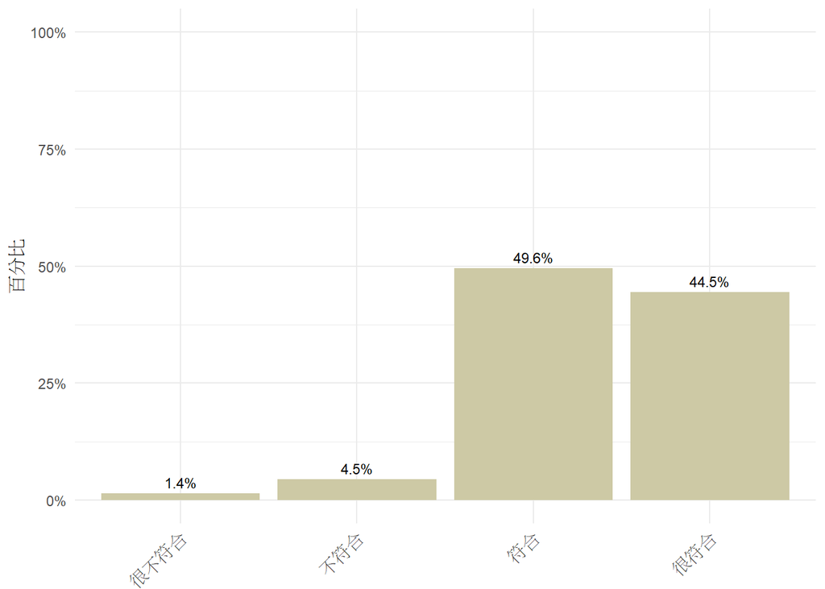